# Project 1: What we have tried (II) #420

I also tried Lasso and Ridge.

### Pre-processing

Next, I describe pre-processing procedures I have used. Note that pre-procedures are subjective. For example, I decide to remove imbalanced categorical variables due to the concern that an indicator variable for just a small set of samples tends to overfit those samples. But how small is small? This is a personal and application-specific decision.

**Remove the following variables**

```r
remove.var <- c('Street', 'Utilities', 'Condition_2', 'Roof_Matl', 'Heating', 'Pool_QC', 'Misc_Feature', 'Low_Qual_Fin_SF', 'Pool_Area', 'Longitude','Latitude')
```

I decide to remove “Longitude” and “Latitude” since I do not think they are interpretable predictors; we already have included some neighborhood variables.

I also remove extremely imbalanced categorical variables with most samples belonging to one category.

**Winsorization**

Apply winsorization on some numerical variables: compute the upper 95% quantile of that variable based on the train data, denoted by M; then replace all values in the train (and also test) that are bigger than M by M.

```r
winsor.vars <- c("Lot_Frontage", "Lot_Area", "Mas_Vnr_Area", "BsmtFin_SF_2", "Bsmt_Unf_SF", "Total_Bsmt_SF", "Second_Flr_SF", 'First_Flr_SF', "Gr_Liv_Area", "Garage_Area", "Wood_Deck_SF", "Open_Porch_SF", "Enclosed_Porch", "Three_season_porch", "Screen_Porch", "Misc_Val")

quan.value <- 0.95
for(var in winsor.vars){
tmp <- train.x[, var]
myquan <- quantile(tmp, probs = quan.value, na.rm = TRUE)
tmp[tmp > myquan] <- myquan
train.x[, var] <- tmp
}
```

The reason is that I feel that the contribution of some area-related variables should be capped. For example, the contribution of the size of a house to the selling price can be well approximated by a linear relationship only within a certain range of the square footage; such contribution usually becomes flat; this is why I winsorize those features.

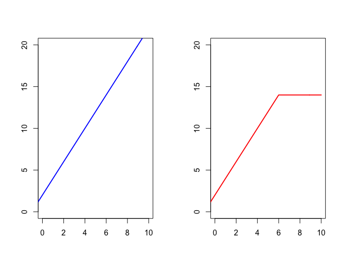

**Categorical Variables**

Follow the same procedure #397 to handle categorical features. In particular, generate K binary dummy variables for any categorical feature with K levels (K>2).

In ordinary linear regression, we generate (K-1) dummy variables (or indicator variables) with one of the K levels set to be the reference level. When all the (K-1) dummy variables are included, it does not matter which level is chosen to be the reference level; if we change the reference level, then the coefficients will change accordingly but the fitted values stay the same (see Quiz 2).

However, with Lasso, we would like to pick a reference level that can lead to a sparse coefficient vector. The solution here is not to pre-specify any reference level; instead, code all K levels as K binary indicator variables.

Yes, the corresponding data matrix will be co-linear, but that’s okay; redundant features won’t be selected by `glmnet` anyway.

### Glmnet

Then I tried `glmnet`. Neither `lambda.min` nor `lambda.1se` returned desirable results.

But the following two models worked!

- Use Lasso with lamda.min to select variables and then fit a Ridge regression model on the selected variables using lambda.min.

```r
cv.out <- cv.glmnet(as.matrix(train.matrix), train.y, alpha = 1)
sel.vars <- predict(cv.out, type="nonzero",
s = cv.out$lambda.min)$X1
cv.out <- cv.glmnet(as.matrix(train.matrix[, sel.vars]),
train.y, alpha = 0)
tmp <-predict(cv.out, s = cv.out$lambda.min,
newx = as.matrix(test.matrix[, sel.vars]))
```

The performance on the 10 splits are

```r
0.1230802
0.1205381
0.1199168
0.1206789
0.1128222
0.1320535
0.1252759
0.1193803
0.1300544
0.1247375
```

- Use elastic net with alpha = 0.2 (I also tried alpha = 0.5, which worked too)

```r
cv.out <- cv.glmnet(as.matrix(train.matrix), train.y, alpha = 0.2)
tmp <-predict(cv.out, s = cv.out$lambda.min, newx = as.matrix(test.matrix))
```

The performance on the 10 splits are

```r
0.1225379
0.117829
0.1202797
0.1196962
0.1114071
0.1332807
0.1258256
0.1201044
0.1292453
0.1233087
```

**Remember** to set seed before `cv.glmnet` so we can reproduce your results; seeds here **do not have to be related to your UIN**.